# Diana Ruiz Moctezuma

## Regresión

### Objetivo dado mi dataset seleccionado: Predecir el precio de cierre de la acción de Coca-Cola (KO) usando modelos de series temporales.

Entrenando con datos históricos hasta 2018, prediciendo del 2019-2025

```python
# Librerias
import pandas as pd
import numpy as np
import matplotlib.pyplot as plt
import seaborn as sns
import scipy.stats as stats
from statsmodels.graphics.tsaplots import plot_acf

from statsmodels.tsa.stattools import adfuller
from statsmodels.tsa.seasonal import seasonal_decompose

from statsmodels.graphics.tsaplots import plot_acf, plot_pacf

from statsmodels.tsa.arima.model import ARIMA
from statsmodels.tsa.statespace.sarimax import SARIMAX


import matplotlib.pyplot as plt
import seaborn as sns


sns.set_theme(style="whitegrid", context="notebook")
plt.rcParams["figure.figsize"] = (12,5)
plt.rcParams["axes.titlesize"] = 14
plt.rcParams["axes.labelsize"] = 12
```

## Dataset

```python
df = pd.read_csv("KO_1919-09-05_2025-09-14.csv", skiprows=[1])
```

## Ordenando por fecha

```python
df["date"] = pd.to_datetime(df["date"])

df = df.sort_values("date")

df = df.set_index("date")
```

```python
df.head()
```

| date | open | high | low | close | adj_close | volume |
| --- | --- | --- | --- | --- | --- | --- |
| 1962-01-02 | 0.263021 | 0.270182 | 0.263021 | 0.263021 | 0.045716 | 806400 |
| 1962-01-03 | 0.259115 | 0.259115 | 0.253255 | 0.257161 | 0.044698 | 1574400 |
| 1962-01-04 | 0.257813 | 0.261068 | 0.257813 | 0.259115 | 0.045037 | 844800 |
| 1962-01-05 | 0.259115 | 0.262370 | 0.252604 | 0.253255 | 0.044019 | 1420800 |
| 1962-01-08 | 0.251302 | 0.251302 | 0.245768 | 0.250651 | 0.043566 | 2035200 |

## Análisis exploratorio

*Target precio de cierre logarítmico (log(close)) del siguiente día.*

```python
serie = df["close"]
```

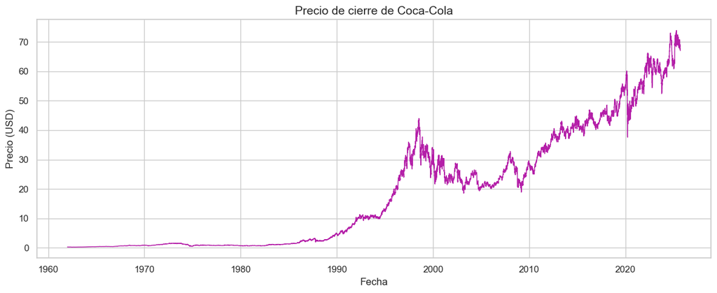

```python
plt.figure()

plt.plot(serie, color="#b41fa8", linewidth=1)

plt.title("Precio de cierre de Coca-Cola")
plt.xlabel("Fecha")
plt.ylabel("Precio (USD)")

plt.tight_layout()
plt.show()
```

```python
serie.describe()
```

```
count    16032.000000
mean        18.811485
std         19.836307
min          0.192057
25%          0.890625
50%         10.656250
75%         32.562500
max         73.900002
Name: close, dtype: float64
```

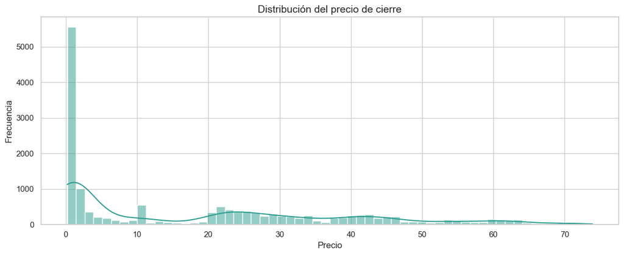

```python
# Histrograma con curva de densidad
plt.figure()

sns.histplot(serie, bins=60, kde=True, color="#2a9d8f")

plt.title("Distribución del precio de cierre")
plt.xlabel("Precio")
plt.ylabel("Frecuencia")

plt.tight_layout()
plt.show()
```

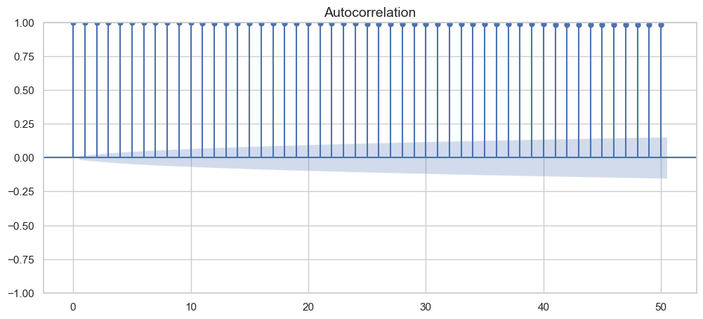

```python
# Autocorrelación
from statsmodels.graphics.tsaplots import plot_acf

plot_acf(serie, lags=50)

plt.show()
```

*Tendencia creciente, no es estacionaria, en histograma distribución sesgada a la decrecha y autocorrelación muy alta en muchos lags (valores pasados), no estacionariedad*

```python
# Valores faltantes
serie.isna().sum()
```

```
0
```

```python
# Transformaciones de la serie
# Reduciendo la influencia de valores muy grandes

serie_log = np.log(serie)
```

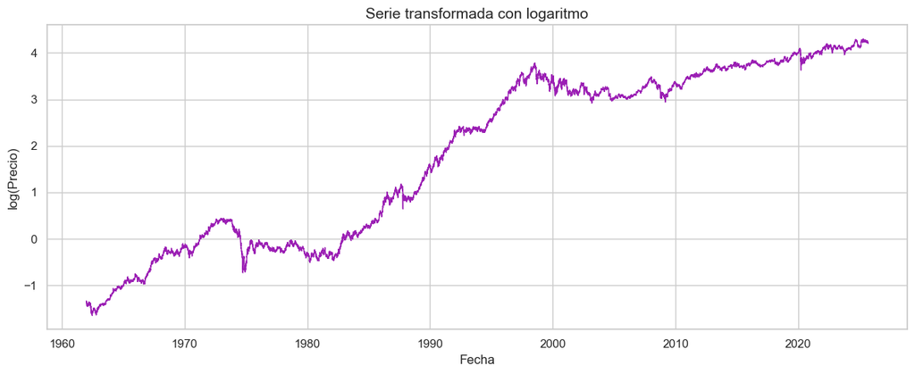

```python
plt.figure()

plt.plot(serie_log, color="#9b1fb4", linewidth=1)

plt.title("Serie transformada con logaritmo")
plt.xlabel("Fecha")
plt.ylabel("log(Precio)")

plt.tight_layout()
plt.show()
```

```python
# Verificar estacionariedad, p > 0.05 es no estacionaria p < 0.05 estacionaria
resultado = adfuller(serie_log)

print("ADF Statistic:", resultado[0])
print("p-value:", resultado[1])
```

```
ADF Statistic: -1.1728493504385793
p-value: 0.6851648573516642
```

```python
# Diferenciación, eliminando la tendencia en la serie
serie_diff = serie_log.diff().dropna()
```

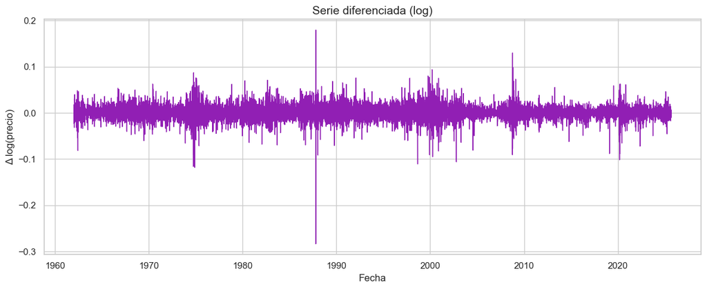

```python
plt.figure(figsize=(12,5))

plt.plot(serie_diff, color="#911fb4", linewidth=1)

plt.title("Serie diferenciada (log)")
plt.xlabel("Fecha")
plt.ylabel("Δ log(precio)")

plt.tight_layout()
plt.show()
```

```python
# Verificando nuevamente estacionariedad
resultado_diff = adfuller(serie_diff)

print("ADF Statistic:", resultado_diff[0])
print("p-value:", resultado_diff[1])
```

```
ADF Statistic: -48.169804060465886
p-value: 0.0
```

*Se aplicó transformación logarítmica para estabilizar la varianza y diferenciación de primer orden para eliminar la tendencia, logrando estacionariedad validada mediante la prueba ADF.*

```python
from statsmodels.tsa.seasonal import seasonal_decompose

decomp = seasonal_decompose(serie_log, model="additive", period=252)
```

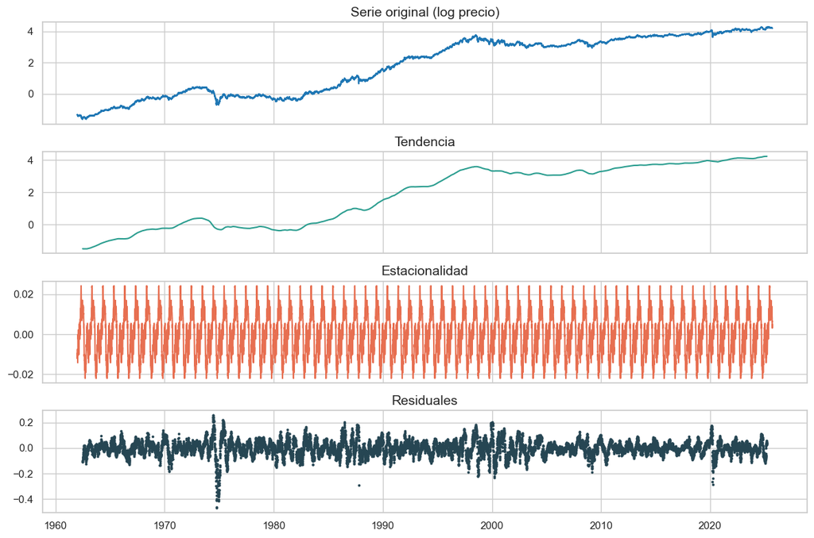

```python
# 252 porque es el número de días de trading en un año
trend = decomp.trend
seasonal = decomp.seasonal
resid = decomp.resid

fig, axes = plt.subplots(4, 1, figsize=(12,8), sharex=True)

axes[0].plot(serie_log, color="#1f77b4")
axes[0].set_title("Serie original (log precio)")

axes[1].plot(trend, color="#2a9d8f")
axes[1].set_title("Tendencia")

axes[2].plot(seasonal, color="#e76f51")
axes[2].set_title("Estacionalidad")

axes[3].scatter(resid.index, resid, s=3, color="#264653")
axes[3].set_title("Residuales")

plt.tight_layout()
plt.show()
```

*La descomposición de la serie temporal muestra una tendencia creciente clara en el precio de la acción de Coca-Cola. El componente estacional presenta variaciones de baja amplitud, lo que sugiere una estacionalidad débil. El componente residual muestra fluctuaciones alrededor de cero, con algunos picos asociados a eventos del mercado. Estos resultados indican que la serie requiere diferenciación para eliminar la tendencia antes de aplicar modelos ARIMA.*

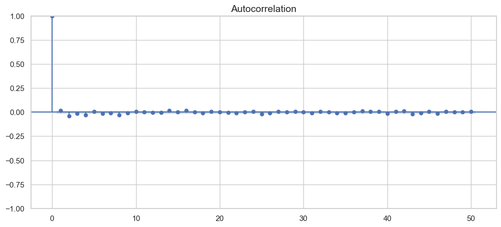

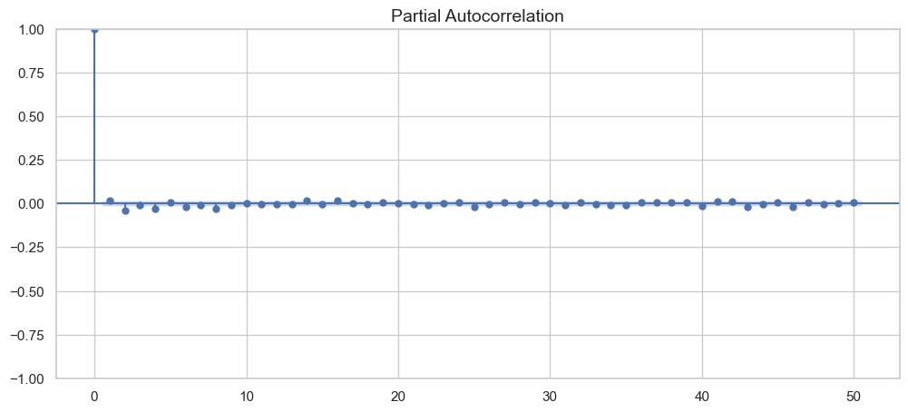

```python
# Determinando ARIMA inicial
from statsmodels.graphics.tsaplots import plot_acf, plot_pacf

plt.figure(figsize=(12,4))
plot_acf(serie_diff, lags=50)
plt.show()

plt.figure(figsize=(12,4))
plot_pacf(serie_diff, lags=50)
plt.show()
```

*En ACF casí todos los valores cerca de cero, sin decaimiento e igual en PACF, la serie está limpia*

## SPLIT

```python
train = serie_log[:'2018']
test = serie_log['2019':]
```

*El split de entrenamiento y prueba se realizó por fechas, usando datos hasta 2018 para entrenar y de 2019 en adelante para evaluar, incluyendo el período de la pandemia COVID-19.*

## ARIMA

```python
from statsmodels.tsa.arima.model import ARIMA

import warnings
warnings.filterwarnings("ignore")

best_aic = float("inf")
best_order = None
best_model = None

for p in range(4):
    for d in range(3):
        for q in range(4):

            try:
                model = ARIMA(train, order=(p,d,q))
                result = model.fit()

                if result.aic < best_aic:
                    best_aic = result.aic
                    best_order = (p,d,q)
                    best_model = result

            except:
                continue
```

```python
print("Mejor modelo ARIMA:", best_order)
print("AIC:", best_aic)
```

```
Mejor modelo ARIMA: (2, 1, 2)
AIC: -80571.82452574222
```

```python
# Training
modelo = ARIMA(train, order=(2,1,2))
resultado = modelo.fit()
```

```python
# Versión rápida — no re-entrena, solo actualiza
resultado = ARIMA(train, order=(2,1,2)).fit()

predicciones = []
for t in range(len(test)):
    pred = resultado.forecast(steps=1).iloc[0]
    predicciones.append(pred)

    # Actualiza sin re-entrenar completamente
    resultado = resultado.append([test.iloc[t]], refit=False)

forecast = pd.Series(predicciones, index=test.index)
```

```python
# Evaluar modelo
from sklearn.metrics import mean_squared_error, mean_absolute_error
import numpy as np

mse = mean_squared_error(test, forecast)
rmse = np.sqrt(mse)
mae = mean_absolute_error(test, forecast)

print("MSE:", mse)
print("RMSE:", rmse)
print("MAE:", mae)
```

```
MSE: 0.0001622274461521729
RMSE: 0.012736853856120549
MAE: 0.00849709271751618
```

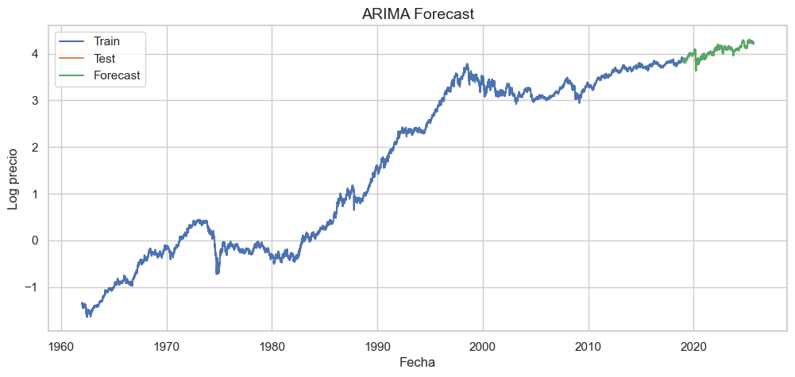

```python
plt.figure(figsize=(12,5))

plt.plot(train.index, train, label="Train")
plt.plot(test.index, test, label="Test")
plt.plot(test.index, forecast, label="Forecast")

plt.legend()
plt.title("ARIMA Forecast")
plt.xlabel("Fecha")
plt.ylabel("Log precio")

plt.show()
```

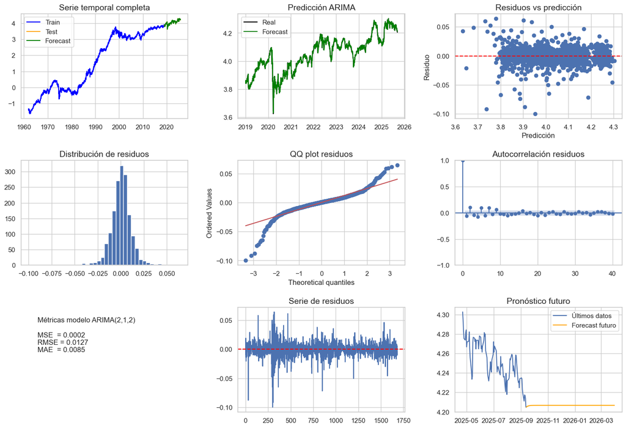

```python
# residuos
residuos = test.values - forecast.values

fig, axes = plt.subplots(3,3, figsize=(18,12))
plt.subplots_adjust(hspace=0.4, wspace=0.3)

# 1️ Serie completa
axes[0,0].plot(train.index, train, label="Train", color="blue")
axes[0,0].plot(test.index, test, label="Test", color="orange")
axes[0,0].plot(test.index, forecast, label="Forecast", color="green")
axes[0,0].set_title("Serie temporal completa")
axes[0,0].legend()
axes[0,0].grid(True)

# 2️ Forecast vs real
axes[0,1].plot(test.index, test, label="Real", color="black")
axes[0,1].plot(test.index, forecast, label="Forecast", color="green")
axes[0,1].set_title("Predicción ARIMA")
axes[0,1].legend()
axes[0,1].grid(True)

# 3  Residuos vs predicción
residual_test = test.values - forecast.values
axes[0,2].scatter(forecast.values, residual_test)
axes[0,2].axhline(0, color="red", linestyle="--")
axes[0,2].set_title("Residuos vs predicción")
axes[0,2].set_xlabel("Predicción")
axes[0,2].set_ylabel("Residuo")
axes[0,2].grid(True)

# 4️ Histograma de residuos
axes[1,0].hist(residuos, bins=40)
axes[1,0].set_title("Distribución de residuos")
axes[1,0].grid(True)

# 5️ QQ plot
stats.probplot(residuos, dist="norm", plot=axes[1,1])
axes[1,1].set_title("QQ plot residuos")

# 6️ Autocorrelación residuos
plot_acf(residuos, ax=axes[1,2], lags=40)
axes[1,2].set_title("Autocorrelación residuos")

# 7️ Métricas
axes[2,0].axis("off")

metrics_text = f"""
Métricas modelo ARIMA(2,1,2)

MSE  = {mse:.4f}
RMSE = {rmse:.4f}
MAE  = {mae:.4f}
"""

axes[2,0].text(0.1,0.5,metrics_text, fontsize=12)

# 8️ Serie de residuos
axes[2,1].plot(residuos)
axes[2,1].axhline(0, linestyle="--", color="red")
axes[2,1].set_title("Serie de residuos")
axes[2,1].grid(True)

# 9️ Pronóstico a futuro
future = resultado.forecast(steps=200)
future_dates = pd.date_range(
    start=test.index[-1],
    periods=201,
    freq=pd.infer_freq(test.index)  # ← detecta frecuencia automáticamente
)[1:]

axes[2,2].plot(test.index[-100:], test[-100:], label="Últimos datos")  # ← test, no train
axes[2,2].plot(future_dates, future, label="Forecast futuro", color="orange")
axes[2,2].set_title("Pronóstico futuro")
axes[2,2].legend()
axes[2,2].grid(True)
```

En series temporales, el supuesto fundamental es que los residuos deben ser independientes, es decir, que el error de hoy no dependa del error de ayer.

- Si ACF de residuos ≈ 0 → el modelo capturó todo lo que podía
- Si ACF de residuos ≠ 0 → el modelo "dejó información sin usar"

### Análsis ARIMA

El orden del modelo fue seleccionado mediante búsqueda automática por criterio AIC sobre parámetros p∈[0,3], d∈[0,2], q∈[0,3]. La evaluación se realizó con predicción one-step-ahead con refit=False, actualizando la historia con cada valor real observado. Este enfoque produjo métricas sólidas con RMSE = 0.0127 y MAE = 0.0085, y los residuos mostraron comportamiento de ruido blanco con autocorrelación prácticamente nula desde el lag 1, que es el diagnóstico ideal para este tipo de modelos. La principal limitación del ARIMA es que para horizontes largos el pronóstico colapsa hacia la media, siendo útil principalmente para predicción de corto plazo.

## ARNet

```python
def create_lags(series, lags=5):
    X = []
    y = []

    for i in range(lags, len(series)):
        X.append(series[i-lags:i])
        y.append(series[i])

    return np.array(X), np.array(y)
```

```python
from sklearn.neural_network import MLPRegressor
from sklearn.preprocessing import StandardScaler
from sklearn.pipeline import Pipeline

lags = 52  # Captura más dependencia temporal (ver ACF)

X_train_lag, y_train_lag = create_lags(train.values, lags)
X_test_lag, y_test_lag   = create_lags(test.values,  lags)

pipeline = Pipeline([
    ("scaler", StandardScaler()),
    ("arnet", MLPRegressor(
        hidden_layer_sizes=(64, 32),  # Más capacidad
        activation="relu",
        solver="adam",
        max_iter=2000,
        alpha=0.001,          # Regularización L2
        learning_rate="adaptive",
        early_stopping=True,  # Evita overfitting
        validation_fraction=0.1,
        random_state=42
    ))
])

pipeline.fit(X_train_lag, y_train_lag)
```

```
Pipeline(steps=[('scaler', StandardScaler()),
                ('arnet',
                 MLPRegressor(alpha=0.001, early_stopping=True,
                              hidden_layer_sizes=(64, 32),
                              learning_rate='adaptive', max_iter=2000,
                              random_state=42))])
```

```
Train
  RMSE : 0.0296
  MAE  : 0.0220
  MAPE : inf%
  R²   : 0.9997

Test
  RMSE : 0.0274
  MAE  : 0.0200
  MAPE : 0.50%
  R²   : 0.9492
```

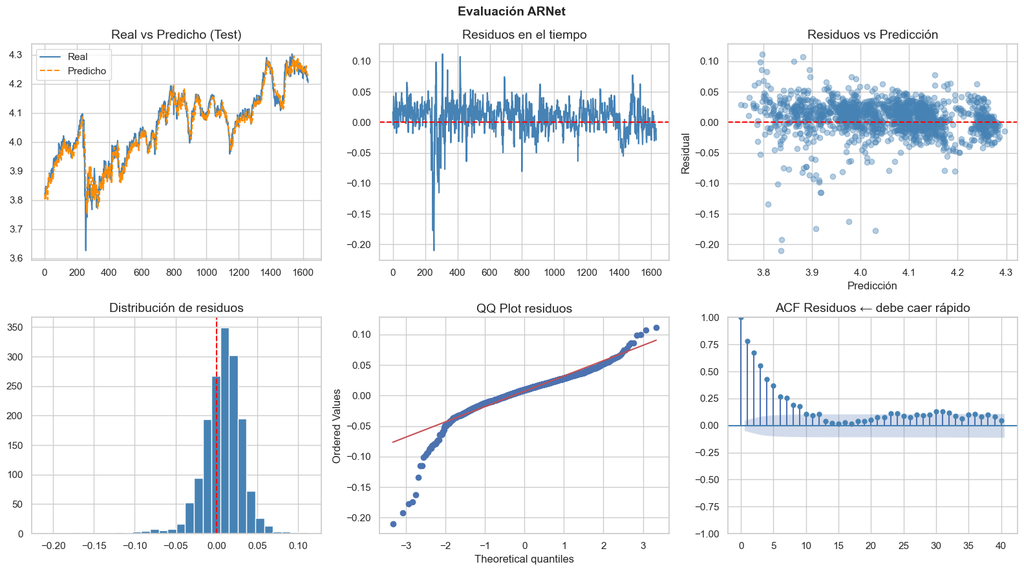

```python
import numpy as np
import matplotlib.pyplot as plt
from sklearn.metrics import mean_squared_error, mean_absolute_error
from scipy import stats

def evaluar_arnet(pipeline, X_train, y_train, X_test, y_test, lags):
    """
    Evaluación completa de un modelo ARNet.
    """
    # Predicciones
    y_train_pred = pipeline.predict(X_train)
    y_test_pred  = pipeline.predict(X_test)

    # Métricas
    def metricas(y_true, y_pred, nombre):
        rmse = np.sqrt(mean_squared_error(y_true, y_pred))
        mae  = mean_absolute_error(y_true, y_pred)
        mape = np.mean(np.abs((y_true - y_pred) / y_true)) * 100
        r2   = 1 - np.sum((y_true - y_pred)**2) / np.sum((y_true - np.mean(y_true))**2)
        print(f"\n{nombre}")
        print(f"  RMSE : {rmse:.4f}")
        print(f"  MAE  : {mae:.4f}")
        print(f"  MAPE : {mape:.2f}%")
        print(f"  R²   : {r2:.4f}")
        return rmse, mae, mape, r2

    metricas(y_train, y_train_pred, "Train")
    metricas(y_test,  y_test_pred,  "Test")

    # Residuos
    residuos = y_test - y_test_pred

    fig, axes = plt.subplots(2, 3, figsize=(16, 9))
    fig.suptitle("Evaluación ARNet", fontsize=14, fontweight="bold")

    # 1. Real vs Predicho (Test)
    ax = axes[0, 0]
    ax.plot(y_test,      label="Real",    color="steelblue")
    ax.plot(y_test_pred, label="Predicho",color="darkorange", linestyle="--")
    ax.set_title("Real vs Predicho (Test)")
    ax.legend()

    # 2. Residuos en el tiempo
    ax = axes[0, 1]
    ax.plot(residuos, color="steelblue")
    ax.axhline(0, color="red", linestyle="--")
    ax.set_title("Residuos en el tiempo")

    # 3. Residuos vs Predicción (heterocedasticidad)
    ax = axes[0, 2]
    ax.scatter(y_test_pred, residuos, alpha=0.4, color="steelblue")
    ax.axhline(0, color="red", linestyle="--")
    ax.set_title("Residuos vs Predicción")
    ax.set_xlabel("Predicción")
    ax.set_ylabel("Residual")

    # 4. Distribución de residuos
    ax = axes[1, 0]
    ax.hist(residuos, bins=30, color="steelblue", edgecolor="white")
    ax.axvline(0, color="red", linestyle="--")
    ax.set_title("Distribución de residuos")

    # 5. QQ Plot
    ax = axes[1, 1]
    stats.probplot(residuos, plot=ax)
    ax.set_title("QQ Plot residuos")

    # 6. ACF de residuos
    from statsmodels.graphics.tsaplots import plot_acf
    plot_acf(residuos, lags=40, ax=axes[1, 2], color="steelblue")
    axes[1, 2].set_title("ACF Residuos ← debe caer rápido")

    plt.tight_layout()
    plt.show()





evaluar_arnet(pipeline, X_train_lag, y_train_lag, X_test_lag, y_test_lag, lags)
```

## Conclusión final

El ARIMA(2,1,2) con evaluación one-step-ahead resultó ser el modelo más preciso y mejor diagnosticado para esta serie. Sin embargo, ambos modelos presentaron dificultades para capturar el shock de volatilidad de 2020, evidenciado en las colas del QQ plot, lo cual es esperable dado que eventos de esa magnitud son estructuralmente diferentes al comportamiento histórico normal de la serie.